# fabricated_project_1

### Описание проекта

Вы работаете в интернет-магазине «Стримчик», который продаёт по всему миру компьютерные игры. Из открытых источников доступны исторические данные о продажах игр, оценки пользователей и экспертов, жанры и платформы (например, Xbox или PlayStation). Вам нужно выявить определяющие успешность игры закономерности. Это позволит сделать ставку на потенциально популярный продукт и спланировать рекламные кампании.

Перед вами данные до 2016 года. Представим, что сейчас декабрь 2016 г., и вы планируете кампанию на 2017-й. Нужно отработать принцип работы с данными. Неважно, прогнозируете ли вы продажи на 2017 год по данным 2016-го или же 2027-й — по данным 2026 года. В наборе данных попадается аббревиатура ESRB (Entertainment Software Rating Board) — это ассоциация, определяющая возрастной рейтинг компьютерных игр. ESRB оценивает игровой контент и присваивает ему подходящую возрастную категорию, например, «Для взрослых», «Для детей младшего возраста» или «Для подростков».

#### Описание данных

- Name — название игры
- Platform — платформа
- Year_of_Release — год выпуска
- Genre — жанр игры
- NA_sales — продажи в Северной Америке (миллионы проданных копий)
- EU_sales — продажи в Европе (миллионы проданных копий)
- JP_sales — продажи в Японии (миллионы проданных копий)
- Other_sales — продажи в других странах (миллионы проданных копий)
- Critic_Score — оценка критиков (максимум 100)
- User_Score — оценка пользователей (максимум 10)
- Rating — рейтинг от организации ESRB (англ. Entertainment Software Rating Board). Эта ассоциация определяет рейтинг компьютерных игр и присваивает им подходящую возрастную категорию.

Данные за 2016 год могут быть неполными.

## Изучение данных

```python
import pandas as pd
import numpy as np
import matplotlib.pyplot as plt
import seaborn as sns

from scipy import stats as st
```

```python
pd.set_option('display.float_format', '{:.2f}'.format)
```

```python
try:
    df = pd.read_csv('games.csv')
except:
    print('Ошибка подгрузки данных')
```

```python
df.sample(7)
```

|  | Name | Platform | Year_of_Release | Genre | NA_sales | EU_sales | JP_sales | Other_sales | Critic_Score | User_Score | Rating |
| --- | --- | --- | --- | --- | --- | --- | --- | --- | --- | --- | --- |
| 16033 | FIFA Soccer 08 | PC | 2007.00 | Sports | 0.00 | 0.01 | 0.00 | 0.00 | 77.00 | 6.1 | E |
| 2453 | The Lord of the Rings: War in the North | X360 | NaN | Action | 0.52 | 0.24 | 0.00 | 0.08 | 61.00 | 7.4 | M |
| 14810 | Kintaihi Shounen no Jiken: Kyakusen Eris-Gou n... | DS | 2009.00 | Adventure | 0.00 | 0.00 | 0.03 | 0.00 | NaN | NaN | NaN |
| 11645 | Deep Fear | SAT | 1998.00 | Adventure | 0.00 | 0.00 | 0.08 | 0.00 | NaN | NaN | NaN |
| 10194 | Shin Sangoku Musou 6 Special | PSP | 2011.00 | Action | 0.00 | 0.00 | 0.11 | 0.00 | NaN | NaN | NaN |
| 13648 | Igor: The Game | DS | 2008.00 | Adventure | 0.04 | 0.00 | 0.00 | 0.00 | 43.00 | tbd | E |
| 6005 | Ken Griffey Jr.'s Slugfest | N64 | 1999.00 | Sports | 0.23 | 0.06 | 0.00 | 0.00 | NaN | NaN | NaN |

```python
df.info()
df.describe().loc[['min','max']]
```

```
<class 'pandas.core.frame.DataFrame'>
RangeIndex: 16715 entries, 0 to 16714
Data columns (total 11 columns):
 #   Column           Non-Null Count  Dtype
---  ------           --------------  -----
 0   Name             16713 non-null  object
 1   Platform         16715 non-null  object
 2   Year_of_Release  16446 non-null  float64
 3   Genre            16713 non-null  object
 4   NA_sales         16715 non-null  float64
 5   EU_sales         16715 non-null  float64
 6   JP_sales         16715 non-null  float64
 7   Other_sales      16715 non-null  float64
 8   Critic_Score     8137 non-null   float64
 9   User_Score       10014 non-null  object
 10  Rating           9949 non-null   object
dtypes: float64(6), object(5)
memory usage: 1.4+ MB
```

|  | Year_of_Release | NA_sales | EU_sales | JP_sales | Other_sales | Critic_Score |
| --- | --- | --- | --- | --- | --- | --- |
| min | 1980.00 | 0.00 | 0.00 | 0.00 | 0.00 | 13.00 |
| max | 2016.00 | 41.36 | 28.96 | 10.22 | 10.57 | 98.00 |

### Вывод

Названия столбцов нужно перевести в нижний регистр; поменять тип данных в столбцах 'Year_of_Release' на int, 'User_Score' на float; обработать пропуски; проверить на дубликаты

## Подготовка данных

### Приведение к нижнему регистру названия столбцов

```python
df.columns = [col.lower() for col in df.columns]
df.columns
```

```
Index(['name', 'platform', 'year_of_release', 'genre', 'na_sales', 'eu_sales',
       'jp_sales', 'other_sales', 'critic_score', 'user_score', 'rating'],
      dtype='object')
```

### Обработка пропусков

#### Столбец 'name'

```python
df[df['name'].isna()]
```

|  | name | platform | year_of_release | genre | na_sales | eu_sales | jp_sales | other_sales | critic_score | user_score | rating |
| --- | --- | --- | --- | --- | --- | --- | --- | --- | --- | --- | --- |
| 659 | NaN | GEN | 1993.00 | NaN | 1.78 | 0.53 | 0.00 | 0.08 | NaN | NaN | NaN |
| 14244 | NaN | GEN | 1993.00 | NaN | 0.00 | 0.00 | 0.03 | 0.00 | NaN | NaN | NaN |

Мы видим две очень старые игры, по которым нет не только названий, но и жанра, каких-либо рейтингов и почти нет продаж - удалим их

```python
df.dropna(subset=['name'], inplace=True)
```

#### Столбец 'year_of_release'

Пустых значений всего 1.6%; год выхода одной и той же игры может отличаться в зависимости от платформы и региона, поэтому корректно заполнить пропуски не представляется возможным; удалим пустые значения

```python
df.dropna(subset=['year_of_release'], inplace=True)
df.reset_index(drop=True, inplace=True)
```

#### Столбцы 'critic_score', 'user_score', 'rating'

tbd - 'to be determined', "to be defined", "to be decided" и т.п., в нашем случае это все равно что значение отсутствует, заменим 'tbd' на пустое значение:

```python
df['user_score'] = df['user_score'].replace('tbd', np.NaN)
```

Пропущенных данных много, но заполнить их хоть сколько-то корректно не предоставляется возможным; даже игры с одинаковым названием могут иметь различный функционал при выходе на разных платформах или в разных регионах; на одних платформах игра работает прекрасно, а на других ужасно; в каких-то регионах игры могут не выходить или регион не имеет рейтинговой системы. Оставим пропуски как есть

```python
df['rating'].value_counts()
```

```
E       3921
T       2905
M       1536
E10+    1393
EC         8
K-A        3
AO         1
RP         1
Name: rating, dtype: int64
```

Есть четыре категории рейтинга, которые статистически незначимы и по смыслу могут быть включены в другие популярные категории, переприсвоим играм с этими рейтингами новые значения: для EC("Early childhood") и K-A("Kids to Adults") - E("Everyone"); AO("Adults Only 18+") - M("Mature"); RP("Rating Pending") - NaN  
Заменим пустые значения на NR (None rating)

```python
df.loc[(df['rating']=='EC') | (df['rating']=='K-A'), ['rating']] = 'E'
df.loc[(df['rating']=='AO'),['rating']] = 'M'
df.loc[(df['rating']=='RP') | (df['rating'].isna()),['rating']] = 'NR'
df['rating'].value_counts()
```

```
NR      6677
E       3932
T       2905
M       1537
E10+    1393
Name: rating, dtype: int64
```

### Приведение данных к нужному типу

Столбцы 'year_of_release' приведем к целочисленному типу, 'user_score' к вещественному:

```python
df['year_of_release'] = df['year_of_release'].astype('int64')
df['user_score'] = df['user_score'].astype('float64')
df.info()
```

```
<class 'pandas.core.frame.DataFrame'>
RangeIndex: 16444 entries, 0 to 16443
Data columns (total 11 columns):
 #   Column           Non-Null Count  Dtype
---  ------           --------------  -----
 0   name             16444 non-null  object
 1   platform         16444 non-null  object
 2   year_of_release  16444 non-null  int64
 3   genre            16444 non-null  object
 4   na_sales         16444 non-null  float64
 5   eu_sales         16444 non-null  float64
 6   jp_sales         16444 non-null  float64
 7   other_sales      16444 non-null  float64
 8   critic_score     7983 non-null   float64
 9   user_score       7463 non-null   float64
 10  rating           16444 non-null  object
dtypes: float64(6), int64(1), object(4)
memory usage: 1.4+ MB
```

### Подсчет суммарных продаж во всех регионах

Создадим для каждой игры столбец 'sales':

```python
df['sales'] = df[['na_sales','eu_sales','jp_sales', 'other_sales']].sum(axis = 1)
df.sample(5)
```

|  | name | platform | year_of_release | genre | na_sales | eu_sales | jp_sales | other_sales | critic_score | user_score | rating | sales |
| --- | --- | --- | --- | --- | --- | --- | --- | --- | --- | --- | --- | --- |
| 12289 | KimiKiss | PS2 | 2006 | Adventure | 0.00 | 0.00 | 0.06 | 0.00 | NaN | NaN | NR | 0.06 |
| 9056 | NFL Blitz 20-03 | GC | 2002 | Sports | 0.11 | 0.03 | 0.00 | 0.00 | 72.00 | NaN | E | 0.14 |
| 14977 | Twinkle * Crusaders GoGo! | PSP | 2010 | Adventure | 0.00 | 0.00 | 0.02 | 0.00 | NaN | NaN | NR | 0.02 |
| 6052 | Pirates of the Caribbean: Dead Man's Chest | PSP | 2006 | Adventure | 0.25 | 0.00 | 0.00 | 0.02 | 52.00 | 8.00 | T | 0.27 |
| 3779 | Tales of Symphonia: Dawn of the New World | Wii | 2008 | Role-Playing | 0.21 | 0.04 | 0.24 | 0.02 | 68.00 | 7.10 | T | 0.51 |

### Проверка на дубликаты

```python
df.duplicated().sum()
```

```
0
```

### Вывод

Сменили регистр на нижний у столбцов, обработали пропуски, заменили тип данных, создали столбец с суммарными продажами, проверили на дубликаты

## Исследовательский анализ данных

### Динамика выхода игр по годам

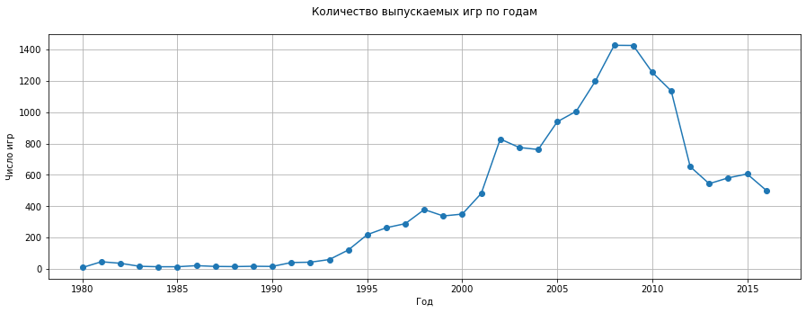

```python
(df
 .pivot_table(index='year_of_release', values='name', aggfunc='count')
 .plot(figsize=(15,5),  style = '-o', grid=True, legend=False)
)
plt.title('Количество выпускаемых игр по годам'+ "\n")
plt.xlabel('Год')
plt.ylabel('Число игр')
plt.show()
```

### Анализ продаж и продолжительность "существования " платформ

#### Определим Top15 платформ с наибольшими суммарными продажами и построим графики распределения продаж по годам

```python
platform_sales = (df
               .pivot_table(index=['platform'], values='sales', aggfunc='sum')
               .nlargest(15, columns=['sales'])
              )
platform_sales
```

| platform | sales |
| --- | --- |
| PS2 | 1233.56 |
| X360 | 961.24 |
| PS3 | 931.34 |
| Wii | 891.18 |
| DS | 802.78 |
| PS | 727.58 |
| PS4 | 314.14 |
| GBA | 312.88 |
| PSP | 289.53 |
| 3DS | 257.81 |
| PC | 255.76 |
| GB | 254.43 |
| XB | 251.57 |
| NES | 251.05 |
| N64 | 218.01 |

```python
#фильтр на Top15 платформ и список этих платформ
platform_15 = df.query('platform in @platform_sales.index')
```

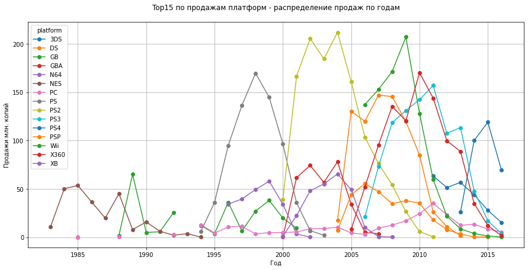

```python
(platform_15
 .pivot_table(index='platform', columns='year_of_release', values='sales', aggfunc='sum')
 .T
 .plot(kind='line', figsize=(15,7), grid=True, style = '-o')
)
plt.title('Top15 по продажам платформ - распределение продаж по годам'+ "\n")
plt.xlabel("Год")
plt.ylabel("Продажи млн. копий")
plt.show()
```

У почти всех платформ из нашего списка "нормальное" распределение - с пиком в середине своего "существования" и неизбежным обнулением продаж в конце; единственное исключение - PC, продажи игр на нем не "блещут", но как платформа персональный компьютер пока бессмертен - это связано с тем, что помимо игр, PC используется для очень широкого круга задач

#### Опредление "срока жизни" игровой платформы

Для всех платформ найдем медиану разниц лет - между первым релизом на и последним, при этом исключим платформы у которых выходили игры в 2016 году, будем считать их еще "живыми"

```python
#вычисляем разность между первым релизом и последним
pl_life_time = df.pivot_table(index='platform', values='year_of_release', aggfunc=[min, max])
pl_life_time.columns = ['first_release', 'last_release']
pl_life_time['life'] = pl_life_time['last_release'] - pl_life_time['first_release']
pl_life_time
```

| platform | first_release | last_release | life |
| --- | --- | --- | --- |
| 2600 | 1980 | 1989 | 9 |
| 3DO | 1994 | 1995 | 1 |
| 3DS | 2011 | 2016 | 5 |
| DC | 1998 | 2008 | 10 |
| DS | 1985 | 2013 | 28 |
| GB | 1988 | 2001 | 13 |
| GBA | 2000 | 2007 | 7 |
| GC | 2001 | 2007 | 6 |
| GEN | 1990 | 1994 | 4 |
| GG | 1992 | 1992 | 0 |
| N64 | 1996 | 2002 | 6 |
| NES | 1983 | 1994 | 11 |
| NG | 1993 | 1996 | 3 |
| PC | 1985 | 2016 | 31 |
| PCFX | 1996 | 1996 | 0 |
| PS | 1994 | 2003 | 9 |
| PS2 | 2000 | 2011 | 11 |
| PS3 | 2006 | 2016 | 10 |
| PS4 | 2013 | 2016 | 3 |
| PSP | 2004 | 2015 | 11 |
| PSV | 2011 | 2016 | 5 |
| SAT | 1994 | 1999 | 5 |
| SCD | 1993 | 1994 | 1 |
| SNES | 1990 | 1999 | 9 |
| TG16 | 1995 | 1995 | 0 |
| WS | 1999 | 2001 | 2 |
| Wii | 2006 | 2016 | 10 |
| WiiU | 2012 | 2016 | 4 |
| X360 | 2005 | 2016 | 11 |
| XB | 2000 | 2008 | 8 |
| XOne | 2013 | 2016 | 3 |

```python
#определяем "живые" платформы
pl_live = df.query('year_of_release == 2016')
list_live = pl_live['platform'].unique()
```

```python
#фильтруем "живые" и находим медиану
pl_dead = pl_life_time.query('platform not in @list_live')
pl_dead['life'].median()
```

```
6.5
```

### Промежуточный вывод

На текущий момент (декабрь 2016) на рынке игровых консолей реально конкурируют между собой только 3 компании - Nintendo, Microsoft и Sony; у каждой компании сейчас есть флагманская модель - WiiU (Nintendo), XOne (Microsoft) и PS4 (Sony), именно среди этих моделей следует искать будущего лидера продаж 2017 года.  
Для прогноза на 2017 год рассмотрим временной период 2013-2016г., он наиболее полно отражает тенденции последних лет - "обвальное" падение числа разработок остановилось и количество выпускаемых игр стабилизировалось в этот период; данные возмем только для платформ, которые были разработаны с 2011 года и позже + "вечный" PC

### Диаграмма размаха глобальных продаж игр в разбивке по платформам

```python
pl_filter = pl_life_time.query('first_release >= 2011')
top_pl = list(set(pl_filter.index)) + ['PC']
#фильтр на платформы и временной период для исследовательского анализа
df_top_pl = df.query('platform in @top_pl and 2013 <= year_of_release <= 2016' )
```

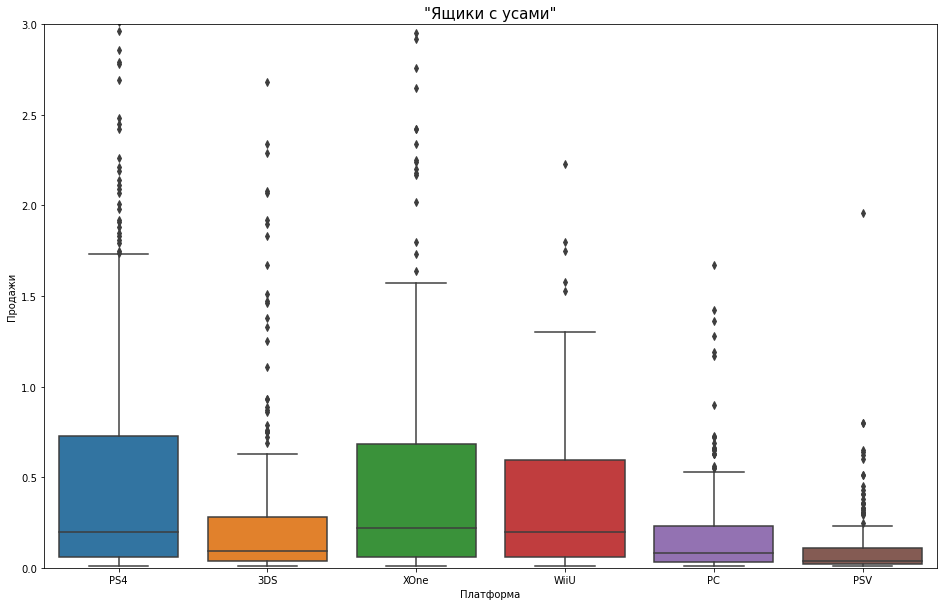

```python
#'ящики с усами'
plt.figure(figsize=(16,10))
sns.boxplot(data=df_top_pl, x='platform', y='sales')
plt.title('"Ящики с усами"', fontsize=15)
plt.xlabel('Платформа', fontsize=10)
plt.ylabel('Продажи',fontsize=10)
plt.ylim(0, 3.0)
plt.show()
```

Медианные продажи у WiiU, XOne и PS4 совпадают; у PSV самый короткий верхний "ус"; у всех платформ большое число "выбросов"

### Влияние на продажи отзывов пользователей и критиков

#### Влияние оценок на продажи на данных платформы PS4

```python
#посчитаем корреляцию между оценками пользователей и продажами
PS4 = df_top_pl.query('platform == "PS4"')
PS4['user_score'].corr(PS4['sales'])
```

```
-0.031957110204556424
```

```python
#посчитаем корреляцию между оценками критиков и продажами
PS4['critic_score'].corr(PS4['sales'])
```

```
0.40656790206178095
```

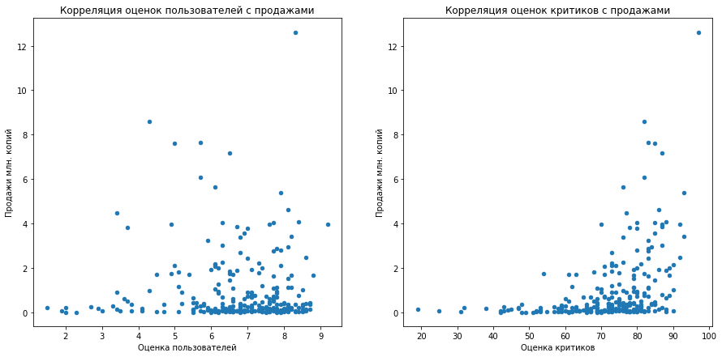

```python
#построим диаграмму рассеивания
fig, ax = plt.subplots(1, 2)
PS4.plot(x='user_score', y='sales', kind='scatter', ax=ax[0], figsize=(15,7))
PS4.plot(x='critic_score', y='sales', kind='scatter', ax=ax[1], figsize=(15,7))
ax[0].set(title='Корреляция оценок пользователей с продажами', xlabel='Оценка пользователей', ylabel='Продажи млн. копий')
ax[1].set(title='Корреляция оценок критиков с продажами', xlabel='Оценка критиков', ylabel='Продажи млн. копий')
plt.show()
```

Оценка пользователей не коррелирует с продажами вообще - у множества высокорейтинговых игр почти "нулевые" продажи, при этом есть игры, которые являются лидерами продаж, но имеют плохой или ниже среднего рейтинг.  
Оценка критиков совпадает с продажами чаще пользовательской, но гарантией хороших продаж также не является. На мой взгляд это связано с тем, что оценка критиков - часть рекламного бюджета, а именно реклама является главным "оружием" для хороших продаж; отсюда - все высокобюджетные игры по "умолчанию" получают хорошие оценки критиков

Соотнесем выводы с продажами и оценками на других платформах

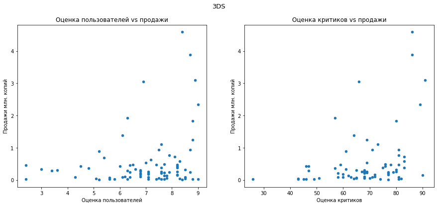

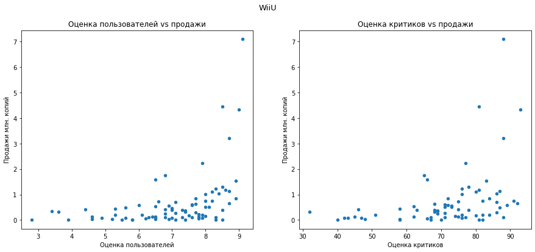

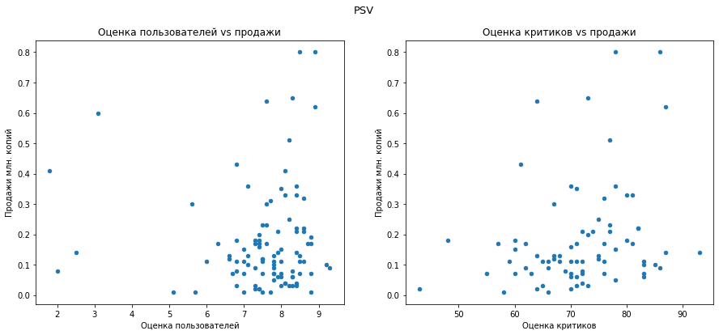

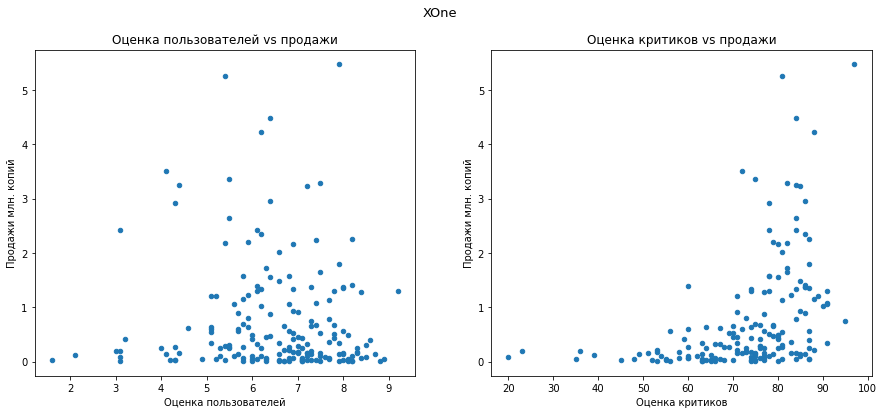

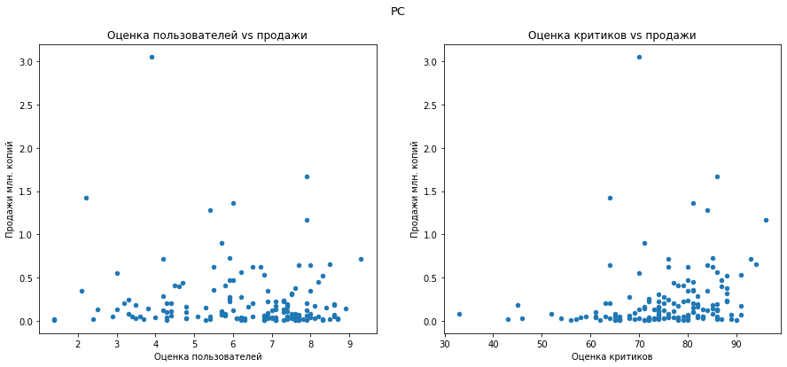

```python
#построим диаграммы рассеивания
top_pl.remove('PS4')
for column in top_pl:
    platform = df_top_pl.query('platform == @column')
    fig, ax = plt.subplots(1, 2)
    platform.plot(x='user_score', y='sales', kind='scatter', ax=ax[0], figsize=(15,6))
    platform.plot(x='critic_score', y='sales', kind='scatter', ax=ax[1], figsize=(15,6))
    fig.suptitle(column, fontsize=13)
    ax[0].set(title='Оценка пользователей vs продажи', xlabel='Оценка пользователей', ylabel='Продажи млн. копий')
    ax[1].set(title='Оценка критиков vs продажи', xlabel='Оценка критиков', ylabel='Продажи млн. копий')
    plt.show()
top_pl.append('PS4')
```

Вывод сделанный по платформе PS4 отлично соотносится с оценками и продажами на других платформах Как итог - пытаться прогнозировать продажи по оценкам, что пользователей, что критиков беспереспективное занятие

### Распределение игр и продаж по жанрам

```python
#колличество выпущенных игр определеных жанров
df_top_pl['genre'].value_counts()
```

```
Action          568
Role-Playing    228
Adventure       169
Sports          127
Shooter         122
Misc            112
Racing           60
Platform         55
Simulation       50
Strategy         49
Fighting         48
Puzzle           16
Name: genre, dtype: int64
```

```python
#посчитаем общие продажи и средние продажи в жанре
genre_df = df_top_pl.pivot_table(index='genre', values='sales', aggfunc={'mean','sum'})
genre_df.columns = ['sales_mean', 'sales_total']
genre_df.sort_values(by='sales_mean', ascending=False)
```

| genre | sales_mean | sales_total |
| --- | --- | --- |
| Shooter | 1.36 | 165.71 |
| Sports | 0.71 | 90.67 |
| Platform | 0.62 | 34.22 |
| Fighting | 0.56 | 26.69 |
| Role-Playing | 0.54 | 123.94 |
| Racing | 0.51 | 30.36 |
| Simulation | 0.40 | 19.81 |
| Action | 0.35 | 199.18 |
| Misc | 0.31 | 34.66 |
| Puzzle | 0.20 | 3.13 |
| Strategy | 0.18 | 8.91 |
| Adventure | 0.10 | 16.48 |

## Портрет пользователя каждого региона

### Самые популярные платформы (NA, EU, JP)

```python
sales_reg = df.pivot_table(index='platform', values=['na_sales','eu_sales','jp_sales'], aggfunc=sum)
sales_reg
```

| platform | eu_sales | jp_sales | na_sales |
| --- | --- | --- | --- |
| 2600 | 4.86 | 0.00 | 80.78 |
| 3DO | 0.00 | 0.10 | 0.00 |
| 3DS | 61.27 | 100.62 | 82.65 |
| DC | 1.69 | 8.56 | 5.43 |
| DS | 188.41 | 175.02 | 380.31 |
| GB | 47.51 | 85.12 | 113.64 |
| GBA | 74.59 | 46.56 | 184.12 |
| GC | 38.32 | 21.34 | 131.94 |
| GEN | 5.52 | 2.67 | 19.27 |
| GG | 0.00 | 0.04 | 0.00 |
| N64 | 41.03 | 33.76 | 138.91 |
| NES | 21.15 | 98.65 | 125.94 |
| NG | 0.00 | 1.44 | 0.00 |
| PC | 140.37 | 0.17 | 93.34 |
| PCFX | 0.00 | 0.03 | 0.00 |
| PS | 212.39 | 139.78 | 334.72 |
| PS2 | 332.63 | 137.54 | 572.92 |
| PS3 | 327.21 | 79.41 | 390.13 |
| PS4 | 141.09 | 15.96 | 108.74 |
| PSP | 65.62 | 75.88 | 107.27 |
| PSV | 13.07 | 21.84 | 12.47 |
| SAT | 0.54 | 32.26 | 0.72 |
| SCD | 0.36 | 0.45 | 1.00 |
| SNES | 19.04 | 116.55 | 61.23 |
| TG16 | 0.00 | 0.16 | 0.00 |
| WS | 0.00 | 1.42 | 0.00 |
| Wii | 258.32 | 68.28 | 486.87 |
| WiiU | 25.13 | 13.01 | 38.10 |
| X360 | 268.32 | 12.30 | 595.74 |
| XB | 59.65 | 1.38 | 182.06 |
| XOne | 51.59 | 0.34 | 93.12 |

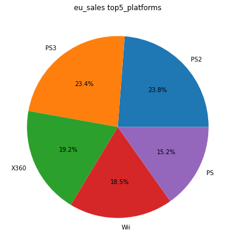

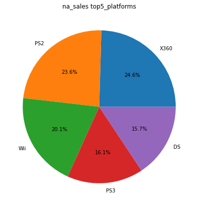

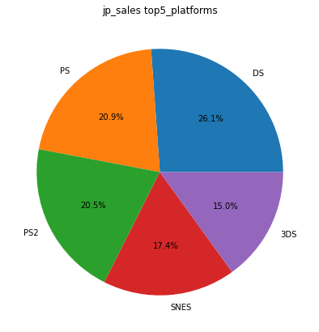

```python
for column in ['eu_sales', 'na_sales', 'jp_sales']:
    (sales_reg.nlargest(5, columns=column)
     .plot(y=column, kind='pie', figsize=(7, 7), title=column+' top5_platforms', autopct='%1.1f%%', legend=False)
    )
    plt.ylabel('')
```

### Самые популярные жанры (NA, EU, JP)

```python
genre_reg = df.pivot_table(index='genre', values=['na_sales','eu_sales','jp_sales'], aggfunc=sum)
genre_reg
```

| genre | eu_sales | jp_sales | na_sales |
| --- | --- | --- | --- |
| Action | 510.99 | 160.14 | 863.17 |
| Adventure | 63.20 | 52.24 | 101.52 |
| Fighting | 99.00 | 87.28 | 220.51 |
| Misc | 210.60 | 107.02 | 399.57 |
| Platform | 199.39 | 130.71 | 444.44 |
| Puzzle | 49.78 | 56.68 | 121.13 |
| Racing | 234.49 | 56.63 | 356.86 |
| Role-Playing | 188.24 | 353.39 | 330.04 |
| Shooter | 314.52 | 38.68 | 584.83 |
| Simulation | 113.35 | 63.64 | 180.40 |
| Sports | 371.33 | 134.93 | 671.20 |
| Strategy | 44.79 | 49.30 | 67.75 |

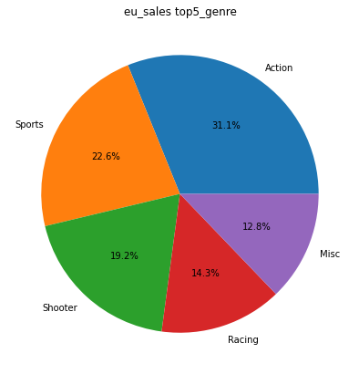

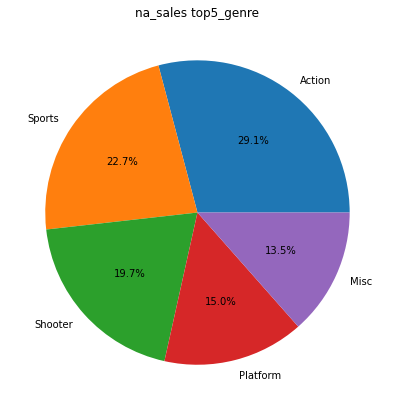

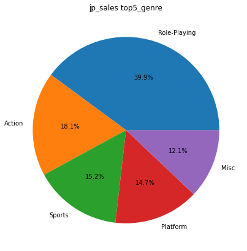

```python
for column in ['eu_sales', 'na_sales', 'jp_sales']:
    (genre_reg.nlargest(5, columns=column)
     .plot(y=column, kind='pie', figsize=(7, 7), title=column+' top5_genre', autopct='%1.1f%%', legend=False)
    )
    plt.ylabel('')
```

### Влияние рейтинга ESRB на продажи (NA, EU, JP)

```python
esrb_reg = df.pivot_table(index='rating', values=['na_sales','eu_sales','jp_sales'], aggfunc=sum)
esrb_reg
```

| rating | eu_sales | jp_sales | na_sales |
| --- | --- | --- | --- |
| E | 704.25 | 199.42 | 1278.33 |
| E10+ | 183.35 | 40.20 | 345.50 |
| M | 480.61 | 63.58 | 744.15 |
| NR | 609.68 | 836.74 | 1225.84 |
| T | 421.79 | 150.70 | 747.60 |

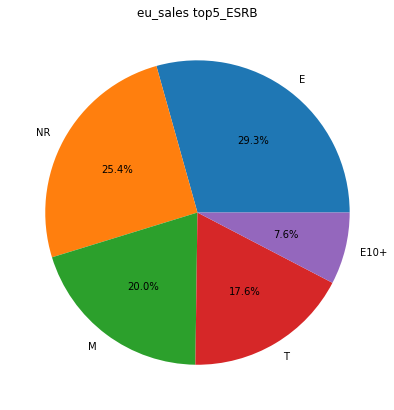

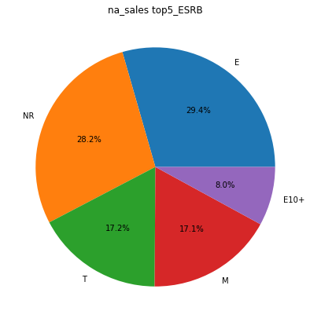

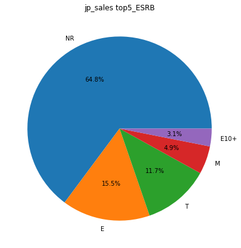

```python
for column in ['eu_sales', 'na_sales', 'jp_sales']:
    (esrb_reg.nlargest(5, columns=column)
     .plot(y=column, kind='pie', figsize=(7, 7), title=column+' top5_ESRB', autopct='%1.1f%%', legend=False)
    )
    plt.ylabel('')
```

- Различий между Европой и Америкой нет - разницей в несколько процентов в отдельных категориях можно пренебречь;
- 2/3 рынка Японии занимают игры без рейтинга ESRB, связано это с тем, что в Японии действует своя рейтинговая система CERO, и хотя закон не обязывает присваивать играм рейтинг, производители приставок заставляют издателей видеоигр оценивать игры по CERO. Оценка по ESRB в таком случае смысла почти не имеет, к тому же она платная;
- Если же в целом говорить о порядке распределении долей то оно вполне логчино - чем шире возрастная аудитория, тем больше доля продаж

## Проверка гипотез

### Средние пользовательские рейтинги платформ Xbox One и PC одинаковые

Сформулируем нулевую и альтернативную гипотезы:

- H0 - Средние пользовательские рейтинги платформ Xbox One и PC одинаковые
- H1 - Средние пользовательские рейтинги платформ Xbox One и PC различаются

```python
#фильтр на платформы и пропуски
xbox_tt = df_top_pl.query('platform == "XOne" and user_score >= 0')['user_score']
pc_tt = df_top_pl.query('platform == "PC" and user_score >= 0')['user_score']

#пороговое значение
alpha = .05
#для проверки гипотезы используем метод ttest_ind
results = st.ttest_ind(pc_tt, xbox_tt, equal_var=False)
print('p-значение:', results.pvalue)
if (results.pvalue < alpha):
    print("Отвергаем нулевую гипотезу")
else:
    print("Не получилось отвергнуть нулевую гипотезу")
```

```
p-значение: 0.14759594013430463
Не получилось отвергнуть нулевую гипотезу
```

Нулевая гипотеза не отвергнута, средние рейтинги у Xone и PC одинаковые

### Средние пользовательские рейтинги жанров Action и Sports разные

Сформулируем нулевую и альтернативную гипотезы:

- H0 - средние пользовательские рейтинги жанров Action и Sports равны
- H1 - средние пользовательские рейтинги жанров Action и Sports различаются

```python
#фильтр на жанры и пропуски
action_tt = df_top_pl.query('genre == "Action" and user_score >= 0')['user_score']
sports_tt = df_top_pl.query('genre == "Sports" and user_score >= 0')['user_score']

#пороговое значение
alpha = .05
#для проверки гипотезы используем метод ttest_ind
results = st.ttest_ind(action_tt, sports_tt, equal_var=False)
print('p-значение:', results.pvalue)
if (results.pvalue < alpha):
    print("Отвергаем нулевую гипотезу")
else:
    print("Не получилось отвергнуть нулевую гипотезу")
```

```
p-значение: 1.2678091455806196e-11
Отвергаем нулевую гипотезу
```

Нулевая гипотеза отвергнута, пользовательские рейтинги для жанров "Action" и "Sports" различаются

### Вывод

Для количественных данных в двух независимых группах, которые распределены нормально, применили Т-критерий Стьюдента для проверки гипотез:

- Гипотеза: "Средние пользовательские рейтинги платформ Xbox one и PC одинаковые". Гипотеза не отвергнута;
- Гипотеза: "Средние пользовательские рейтинги жанров Action и Sports разные". Нулевая гипотеза "Средние пользовательские рейтинги жанров Action и Sports равны", отвергнута